## BRC Census

# Perspectives on Burning Man

## Burning Man Attendance, Self-Identification as a "Burner," Burning Man Year-Round, and Funding Priorities

## Burning Man Attendance

### Reasons for Going to Black Rock City This Year*

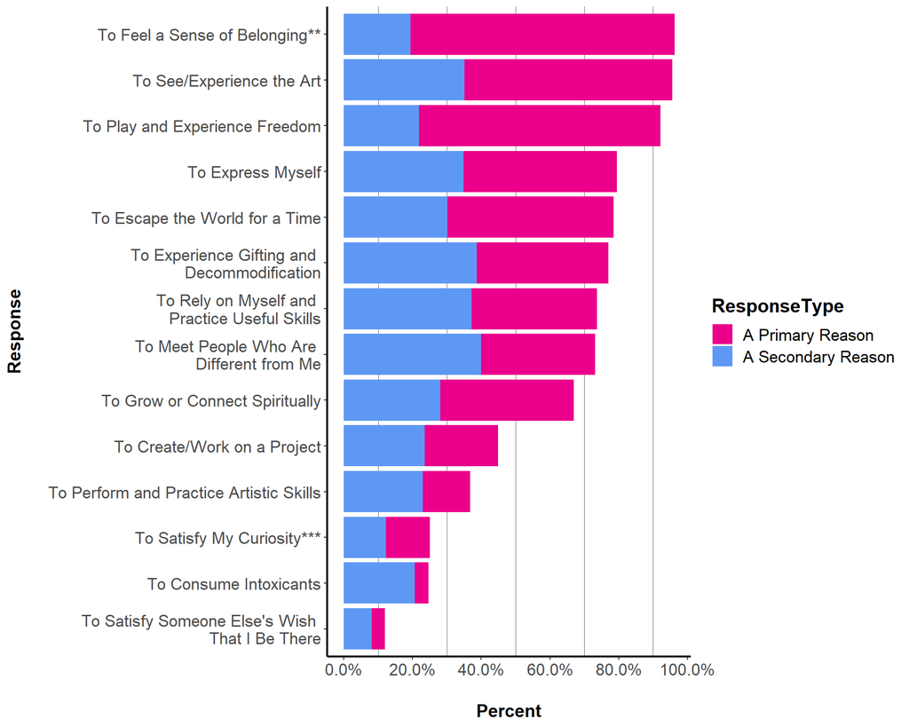

* Participants selected up to three options. Question options were changed in 2019 and are not comaprable to previous years.  
** The exact wording of the answer option in the online survey was, "To be with friends or like-minded people / feel a sense of belonging."  
*** The exact wording of the answer option in the online survey was, "To satisfy my curiosity / check it off my 'bucket list.'"

[output not shown]

## Burning Man Attendance

# Evaluation of Intent to Return to Black Rock City in the Future

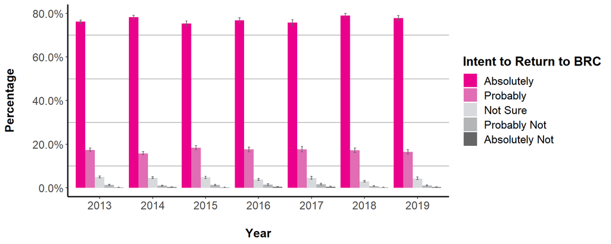

Error bars indicate the upper and lower bounds of the 95% confidence intervals.

|  | 2013 Percent | 2013 MoE +/- % |  | 2014 Percent | 2014 MoE +/- % |  | 2015 Percent | 2015 MoE +/- % |  | 2016 Percent | 2016 MoE +/- % |  | 2017 Percent | 2017 MoE +/- % |  | 2018 Percent | 2018 MoE +/- % |  | 2019 Percent | 2019 MoE +/- % |
| --- | --- | --- | --- | --- | --- | --- | --- | --- | --- | --- | --- | --- | --- | --- | --- | --- | --- | --- | --- | --- |
| Absolutely | 76.1 | 0.8 |  | 78.2 | 1.0 |  | 75.3 | 1.0 |  | 76.8 | 1.2 |  | 75.7 | 1.4 |  | 78.9 | 1.2 |  | 77.8 | 1.2 |
| Probably | 17.4 | 0.8 |  | 15.8 | 0.8 |  | 18.4 | 1.0 |  | 17.6 | 1.2 |  | 17.6 | 1.2 |  | 17.2 | 1.0 |  | 16.5 | 1.0 |
| Not Sure | 4.9 | 0.4 |  | 4.6 | 0.4 |  | 4.8 | 0.6 |  | 3.8 | 0.6 |  | 4.6 | 0.6 |  | 3.0 | 0.4 |  | 4.3 | 0.6 |
| Probably Not | 1.4 | 0.2 |  | 1.0 | 0.2 |  | 1.3 | 0.2 |  | 1.5 | 0.4 |  | 1.6 | 0.4 |  | 0.8 | 0.2 |  | 1.1 | 0.2 |
| Absolutely Not | 0.2 | 0.0 |  | 0.3 | 0.2 |  | 0.2 | 0.0 |  | 0.4 | 0.2 |  | 0.5 | 0.2 |  | 0.2 | 0.2 |  | 0.3 | 0.2 |

## Self-Identification as a “Burner”

# Self-Identification as a “Burner”

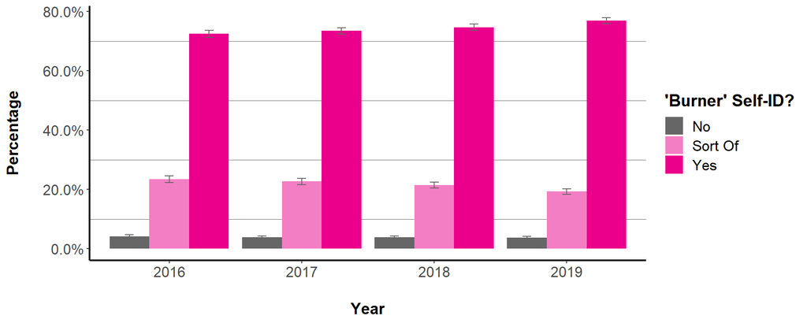

Error bars indicate the upper and lower bounds of the 95% confidence intervals.

|  | 2016 Percent | 2016 MoE +/- % |  | 2017 Percent | 2017 MoE +/- % |  | 2018 Percent | 2018 MoE +/- % |  | 2019 Percent | 2019 MoE +/- % |
| --- | --- | --- | --- | --- | --- | --- | --- | --- | --- | --- | --- |
| No | 4.1 | 0.6 |  | 3.8 | 0.4 |  | 3.8 | 0.4 |  | 3.7 | 0.4 |
| Sort Of | 23.4 | 1.2 |  | 22.7 | 1.0 |  | 21.4 | 1.0 |  | 19.3 | 1.0 |
| Yes | 72.5 | 1.2 |  | 73.5 | 1.2 |  | 74.7 | 1.0 |  | 77.0 | 1.0 |

## Burning Man Year-Round

# Attendance at Regional Events/Mixers/Gatherings

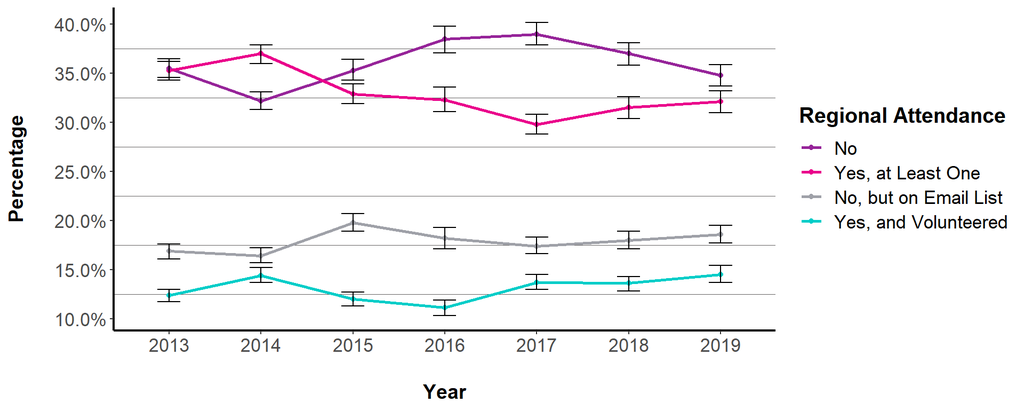

Error bars indicate the upper and lower bounds of the 95% confidence intervals.

|  | 2013 Percent | 2013 MoE +/- % |  | 2014 Percent | 2014 MoE +/- % |  | 2015 Percent | 2015 MoE +/- % |  | 2016 Percent | 2016 MoE +/- % |  | 2017 Percent | 2017 MoE +/- % |  | 2018 Percent | 2018 MoE +/- % |  | 2019 Percent | 2019 MoE +/- % |
| --- | --- | --- | --- | --- | --- | --- | --- | --- | --- | --- | --- | --- | --- | --- | --- | --- | --- | --- | --- | --- |
| No | 35.5 | 1.0 |  | 32.2 | 1.0 |  | 35.3 | 1.0 |  | 38.5 | 1.4 |  | 39.0 | 1.2 |  | 37.0 | 1.2 |  | 34.8 | 1.2 |
| Yes, at Least One | 35.3 | 1.0 |  | 37.0 | 1.0 |  | 32.9 | 1.0 |  | 32.3 | 1.2 |  | 29.8 | 1.0 |  | 31.5 | 1.0 |  | 32.1 | 1.2 |
| No, but on Email List | 16.9 | 0.8 |  | 16.4 | 0.8 |  | 19.8 | 0.8 |  | 18.2 | 1.0 |  | 17.4 | 0.8 |  | 18.0 | 1.0 |  | 18.6 | 1.0 |
| Yes, and Volunteered | 12.4 | 0.6 |  | 14.4 | 0.8 |  | 12.0 | 0.8 |  | 11.1 | 0.8 |  | 13.7 | 0.8 |  | 13.6 | 0.8 |  | 14.5 | 0.8 |

## Burning Man Year-Round

# Regional Burning Man Event Involvement*

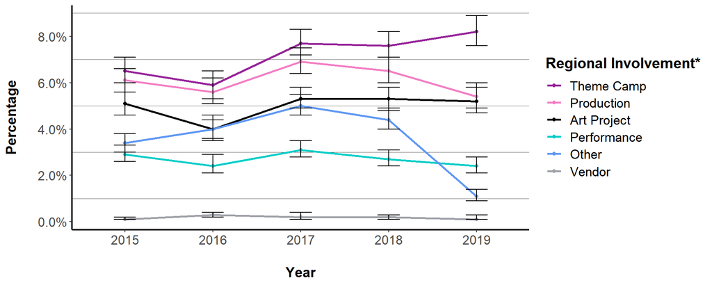

Error bars indicate the upper and lower bounds of the 95% confidence intervals.

* Responses reported here are from participants who indicated having volunteered with at least one regional Burning Man event/gathering/mixer. Participants selected all option(s) that applied.

|  | 2015 Percent | 2015 MoE +/- % |  | 2016 Percent | 2016 MoE +/- % |  | 2017 Percent | 2017 MoE +/- % |  | 2018 Percent | 2018 MoE +/- % |  | 2019 Percent | 2019 MoE +/- % |
| --- | --- | --- | --- | --- | --- | --- | --- | --- | --- | --- | --- | --- | --- | --- |
| Theme Camp | 6.5 | 0.6 |  | 5.9 | 0.6 |  | 7.7 | 0.6 |  | 7.6 | 0.6 |  | 8.2 | 0.6 |
| Production | 6.1 | 0.6 |  | 5.6 | 0.6 |  | 6.9 | 0.6 |  | 6.5 | 0.6 |  | 5.4 | 0.6 |
| Art Project | 5.1 | 0.4 |  | 4.0 | 0.4 |  | 5.3 | 0.4 |  | 5.3 | 0.6 |  | 5.2 | 0.6 |
| Performance | 2.9 | 0.4 |  | 2.4 | 0.4 |  | 3.1 | 0.4 |  | 2.7 | 0.4 |  | 2.4 | 0.4 |
| Other | 3.4 | 0.4 |  | 4.0 | 0.6 |  | 5.0 | 0.4 |  | 4.4 | 0.4 |  | 1.1 | 0.2 |
| Vendor | 0.1 | 0.0 |  | 0.3 | 0.2 |  | 0.2 | 0.2 |  | 0.2 | 0.0 |  | 0.1 | 0.0 |

## Burning Man Year-Round

# Evaluation of Whether the Burning Man Organization Should Be Involved in Facilitating and Producing Year-Round Activities

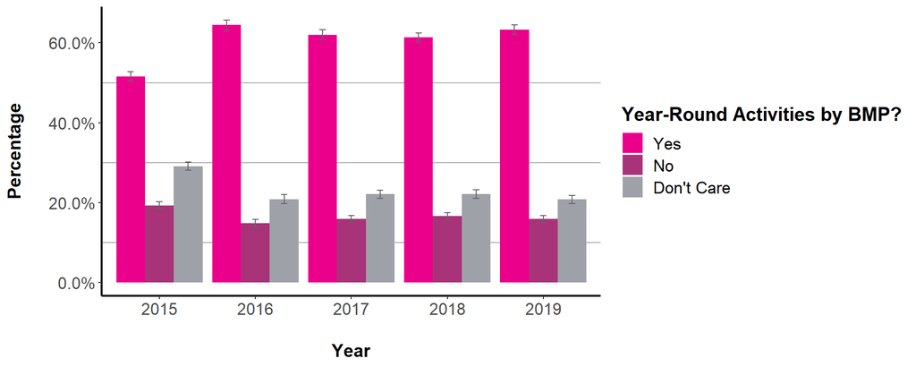

Error bars indicate the upper and lower bounds of the 95% confidence intervals.

|  | 2015 Percent | 2015 MoE +/- % |  | 2016 Percent | 2016 MoE +/- % |  | 2017 Percent | 2017 MoE +/- % |  | 2018 Percent | 2018 MoE +/- % |  | 2019 Percent | 2019 MoE +/- % |
| --- | --- | --- | --- | --- | --- | --- | --- | --- | --- | --- | --- | --- | --- | --- |
| Yes | 51.6 | 1.2 |  | 64.4 | 1.4 |  | 62.0 | 1.2 |  | 61.3 | 1.2 |  | 63.3 | 1.2 |
| No | 19.3 | 1.0 |  | 14.8 | 1.0 |  | 15.9 | 1.0 |  | 16.6 | 1.0 |  | 15.9 | 1.0 |
| Don’t Care | 29.1 | 1.0 |  | 20.8 | 1.2 |  | 22.1 | 1.0 |  | 22.1 | 1.0 |  | 20.8 | 1.0 |

## Burning Man Year-Round

# Familiarity with Programs and Affiliates of the Nonprofit Burning Man Program

[figure not shown]

Error bars indicate the upper and lower bounds of the 95% confidence intervals.

* "Black Rock Labs" was listed in as "Black Rock Solar" in the 2015-17 online surveys.  
** "Fly Ranch Project" was provided as an option in 2018 and 2019. "Burning Man Fellows Program" was an option only in the 2018 online survey.

|  | 2015 Percent | 2015 MoE +/- % |  | 2016 Percent | 2016 MoE +/- % |  | 2017 Percent | 2017 MoE +/- % |  | 2018 Percent | 2018 MoE +/- % |  | 2019 Percent | 2019 MoE +/- % |
| --- | --- | --- | --- | --- | --- | --- | --- | --- | --- | --- | --- | --- | --- | --- |
| Burners Without Borders |  |  |  |  |  |  |  |  |  |  |  |  |  |  |
| Not Familiar | 13.4 | 0.8 |  | 15.0 | 1.0 |  | 13.4 | 0.8 |  | 11.8 | 0.8 |  | 11.6 | 0.8 |
| Heard of It | 37.5 | 1.2 |  | 38.8 | 1.4 |  | 32.5 | 1.2 |  | 35.6 | 1.2 |  | 32.6 | 1.2 |
| Familiar with It | 49.0 | 1.2 |  | 46.3 | 1.4 |  | 54.0 | 1.2 |  | 52.6 | 1.2 |  | 55.7 | 1.2 |
| Burning Man Arts |  |  |  |  |  |  |  |  |  |  |  |  |  |  |
| Not Familiar | 25.5 | 1.0 |  | 30.0 | 1.4 |  | 29.9 | 1.2 |  | 25.2 | 1.0 |  | 24.8 | 1.0 |
| Heard of It | 33.8 | 1.0 |  | 33.3 | 1.4 |  | 32.0 | 1.0 |  | 33.7 | 1.2 |  | 31.8 | 1.2 |
| Familiar with It | 40.7 | 1.2 |  | 36.7 | 1.4 |  | 38.1 | 1.2 |  | 41.1 | 1.2 |  | 43.4 | 1.2 |
| Burning Man Regional Network |  |  |  |  |  |  |  |  |  |  |  |  |  |  |
| Not Familiar | 22.7 | 1.0 |  | 25.5 | 1.2 |  | 28.3 | 1.0 |  | 28.5 | 1.2 |  | 26.2 | 1.0 |
| Heard of It | 35.0 | 1.2 |  | 36.9 | 1.4 |  | 34.9 | 1.2 |  | 35.3 | 1.2 |  | 33.3 | 1.2 |
| Familiar with It | 42.4 | 1.2 |  | 37.6 | 1.4 |  | 36.8 | 1.2 |  | 36.2 | 1.2 |  | 40.5 | 1.2 |
| Fly Ranch Project** |  |  |  |  |  |  |  |  |  |  |  |  |  |  |
| Not Familiar | NA | NA |  | NA | NA |  | NA | NA |  | 41.9 | 1.2 |  | 36.7 | 1.2 |
| Heard of It | NA | NA |  | NA | NA |  | NA | NA |  | 27.0 | 1.0 |  | 27.1 | 1.0 |
| Familiar with It | NA | NA |  | NA | NA |  | NA | NA |  | 31.1 | 1.0 |  | 36.2 | 1.2 |
| Black Rock Labs* |  |  |  |  |  |  |  |  |  |  |  |  |  |  |
| Not Familiar | 39.0 | 1.2 |  | 47.8 | 1.4 |  | 52.1 | 1.2 |  | 57.1 | 1.2 |  | 52.4 | 1.2 |
| Heard of It | 26.1 | 1.0 |  | 24.5 | 1.2 |  | 21.8 | 1.0 |  | 23.7 | 1.0 |  | 25.1 | 1.0 |
| Familiar with It | 35.0 | 1.2 |  | 27.7 | 1.2 |  | 26.2 | 1.0 |  | 19.2 | 1.0 |  | 22.5 | 1.0 |
| Burning Man Fellows Program** |  |  |  |  |  |  |  |  |  |  |  |  |  |  |
| Not Familiar | NA | NA |  | NA | NA |  | NA | NA |  | 81.7 | 1.0 |  | NA | NA |
| Heard of It | NA | NA |  | NA | NA |  | NA | NA |  | 14.0 | 0.8 |  | NA | NA |
| Familiar with It | NA | NA |  | NA | NA |  | NA | NA |  | 4.3 | 0.4 |  | NA | NA |

## Funding Priorities

# If You Were Given $1,000 to Donate to Programs of the Burning Man Project, How Would You Want it to be Distributed*?

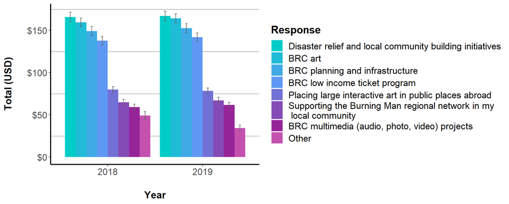

Error bars indicate the upper and lower bounds of the 95% confidence intervals.

* Participants were asked to provide a dollar amount for each option provided, up to $1,000 total across all options.

|  | 2019 Total (USD) | 2019 MoE +/- % |  | 2018 Total (USD) | 2018 MoE +/- % |
| --- | --- | --- | --- | --- | --- |
| Disaster relief and local community building initiatives | $167.09 | $5.82 |  | $166.00 | $5.66 |
| BRC art | $164.25 | $5.37 |  | $159.46 | $5.00 |
| BRC planning and infrastructure | $152.77 | $5.31 |  | $149.18 | $5.21 |
| BRC low income ticket program | $141.96 | $4.94 |  | $137.78 | $5.00 |
| Placing large interactive art in public places abroad | $78.25 | $3.47 |  | $79.91 | $3.53 |
| Supporting the Burning Man regional network in my local community | $67.11 | $3.61 |  | $64.84 | $3.35 |
| BRC multimedia (audio, photo, video) projects | $61.55 | $3.43 |  | $59.18 | $3.51 |
| Other | $34.24 | $3.63 |  | $49.17 | $4.65 |

*BRC Census has included similar questions in past years’ online survey, but the question was revised in 2018 so past responses are not directly comparable.*

**Next:** Life in BRC: Experiences in Black Rock City, Community as Family, and Money Handling